# The_Analytics_Edge_edX_MIT15.071x_June2015_3

### VIDEO 6: CROSS-VALIDATION (R script reproduced here)

In *CART*, the value of `minbucket` can affect the model’s out-of-sample accuracy.  
As we discussed above, if `minbucket` is **too small**, over-fitting might occur. On the other hand, if `minbucket` is **too large**, the model might be too simple.

**So how should we set this parameter value?**

We could select the value that gives the best testing set accuracy, but this would not be right. The idea of the testing set is to measure model performance on data the model has never seen before. By picking the value of `minbucket` to get the best test set performance, the testing set was implicitly used to generate the model.

Instead, we will use a method called **K-fold Cross Validation**, which is one way to properly select the parameter value.

**K-fold Cross Validation**

This method works by going through the following steps.

- First, we split the training set into $k$ equally sized *subsets*, or *folds*. In this example, k equals 5.
- Then we select $k - 1$ or four folds to estimate the model, and compute predictions on the remaining one fold, which is often referred to as the **validation set**.
- We build a model and make predictions for each possible parameter value we are considering.
- We **repeat** this for each of the other folds.

Ultimately *cross validation* builds many models, one for each fold and possible parameter value. Then, for each candidate parameter value, and for each fold, we can compute the accuracy of the model.

This plot shows the possible parameter values on the X-axis, and the accuracy of the model on the Y-axis, with one line for each of the $k$ repeats of the experiment.

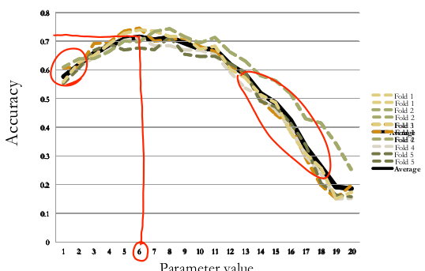

example

We then average the accuracy over the $k$ folds to determine the final parameter value that we want to use.

Typically, the behavior looks like the curves shown in the plot:

- if the parameter value is too small, then the accuracy is lower, because the model is probably over-fit to the training set.
- if the parameter value is too large, then the accuracy is also lower, because the model is too simple.

In this case, we **would pick a parameter value around 6**, because it leads to the maximum average accuracy over all parameter values.

**CV in R**

So far, we have used the parameter `minbucket` to limit our tree in R.  
When we use cross validation in R, we will use a parameter called `cp` instead, the **complexity parameter**.

It is like *Adjusted $R^2$* for linear regression, and *AIC* for logistic regression, in that it **measures the trade-off between model complexity and accuracy** on the training set.

A smaller `cp` value leads to a bigger tree, so a smaller `cp` value might over-fit the model to the training set. But a `cp` value that is too large might build a model that is too simple.

```r
# VIDEO 6

# Install cross-validation packages
#install.packages("caret")
library(caret)
#install.packages("e1071")
library(e1071)

# Define cross-validation experiment
numFolds = trainControl( method = "cv", number = 10 )
cpGrid = expand.grid( .cp = seq(0.01,0.5,0.01))
#This will define our cp parameters to test as numbers from 0.01 to 0.5, in increments of 0.01.

# Perform the cross validation
save_CV<-train(Reverse ~ Circuit + Issue + Petitioner + Respondent + LowerCourt + Unconst, data = Train, method = "rpart", trControl = numFolds, tuneGrid = cpGrid )
save_CV
```

```
## CART
##
## 396 samples
##   8 predictor
##   2 classes: '0', '1'
##
## No pre-processing
## Resampling: Cross-Validated (10 fold)
## Summary of sample sizes: 357, 356, 357, 356, 357, 356, ...
## Resampling results across tuning parameters:
##
##   cp    Accuracy   Kappa
##   0.01  0.6433974  0.267916905
##   0.02  0.6359615  0.248964339
##   0.03  0.6208974  0.225208239
##   0.04  0.6333974  0.258053232
##   0.05  0.6436538  0.283134471
##   0.06  0.6436538  0.283134471
##   0.07  0.6436538  0.283134471
##   0.08  0.6436538  0.283134471
##   0.09  0.6436538  0.283134471
##   0.10  0.6436538  0.283134471
##   0.11  0.6436538  0.283134471
##   0.12  0.6436538  0.283134471
##   0.13  0.6436538  0.283134471
##   0.14  0.6436538  0.283134471
##   0.15  0.6436538  0.283134471
##   0.16  0.6436538  0.283134471
##   0.17  0.6436538  0.283134471
##   0.18  0.6436538  0.283134471
##   0.19  0.6436538  0.283134471
##   0.20  0.6061538  0.188881247
##   0.21  0.5808333  0.122201772
##   0.22  0.5605769  0.063162246
##   0.23  0.5479487  0.021739130
##   0.24  0.5453846  0.009090909
##   0.25  0.5453846  0.000000000
##   0.26  0.5453846  0.000000000
##   0.27  0.5453846  0.000000000
##   0.28  0.5453846  0.000000000
```

[output cut: 10 more lines]

```
##   0.39  0.5453846  0.000000000
##   0.40  0.5453846  0.000000000
##   0.41  0.5453846  0.000000000
##   0.42  0.5453846  0.000000000
##   0.43  0.5453846  0.000000000
##   0.44  0.5453846  0.000000000
##   0.45  0.5453846  0.000000000
##   0.46  0.5453846  0.000000000
##   0.47  0.5453846  0.000000000
##   0.48  0.5453846  0.000000000
##   0.49  0.5453846  0.000000000
##   0.50  0.5453846  0.000000000
##
## Accuracy was used to select the optimal model using  the largest value.
## The final value used for the model was cp = 0.19.
```

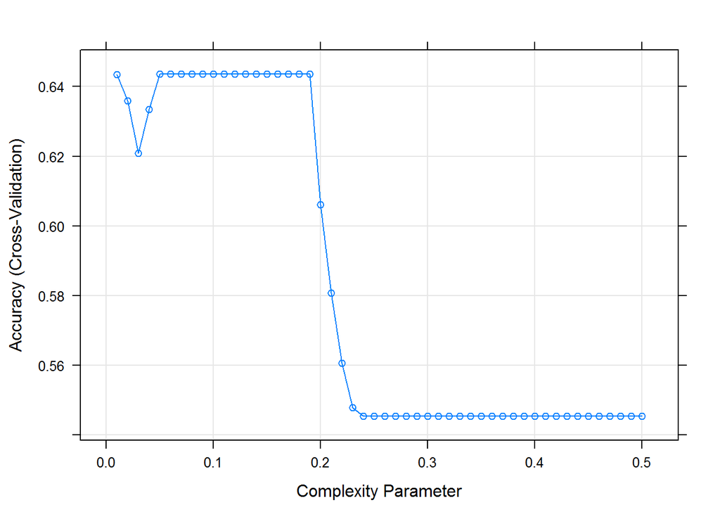

```r
#We get a table describing the cross validation accuracy for different cp parameters.
#The first column gives the cp parameter that was tested
#The second column gives the cross validation accuracy for that cp value.
#The accuracy starts lower, and then increases, and then will start decreasing again, as we saw in the example shown above.

plot(save_CV) #or
```